# pandas_maths

```python
# Tanushri Nayak
```

**Notes:**

- The quiz lasts **30 min**
- **Submission instructions** are available on Kitt

# Quiz Data toolkit

## Part 1/3: Numpy 💠

### Q1❓Create a `ndarray` of integers with 2 dimensions and store it in a `A` variable. Check how many individual integers it comprises of.

```python
# YOUR CODE HERE
import numpy as np
A = np.array([[2,3],[1,4]])

print(A)
print(A.shape)
print(A.size)

A.size
```

```
[[2 3]
 [1 4]]
(2, 2)
4
```

```
4
```

### Q2❓Using the same array `A` , compute the maximum element in each row.

```python
# YOUR CODE HERE
np.max(A[0])
print(np.max(A[0]))
np.max(A[1])
print(np.max(A[1]))
```

```
3
4
```

### Q3❓Given the array B, select its third column (including all the rows). Store it in a `selection` variable.

```python
B = np.array([[1,2,3,4,5], [6,7,8,9,10], [11,12,13,14,15], [16,17,18,19,20]])
B
```

```
array([[ 1,  2,  3,  4,  5],
       [ 6,  7,  8,  9, 10],
       [11, 12, 13, 14, 15],
       [16, 17, 18, 19, 20]])
```

```python
# YOUR CODE HERE
B[:,2]
```

```
array([ 3,  8, 13, 18])
```

### Q4❓Rewrite the loop below in using NumPy broadcasting operator `+`. Store it in `vectorial_sum` variable.

```python
my_list = [
    [6, 5],
    [1, 3],
    [5, 6],
    [1, 4],
    [3, 7],
    [5, 8],
    [3, 5],
    [8, 4],
]

# Python way
sums = []
for row in my_list:
    sums.append(row[0] + row[1]) # standard integer "+" operator
sums
```

```
[11, 4, 11, 5, 10, 13, 8, 12]
```

```python
# your code here, using `my_list` from previous cell

lst = np.array(my_list)
vectorial_sum = lst[:,0] + lst[:,1]
print(vectorial_sum)
```

```
[11  4 11  5 10 13  8 12]
```

## Part 2/3: Pandas 🐼

### Q5❓We loaded for you the `tips` dataset. For this dataset, give a quick overview in about 5 cells and without graphs.

```python
import seaborn as sns
df = sns.load_dataset('tips')
```

```python
# YOUR CODE HERE
df.head(5)
```

|  | total_bill | tip | sex | smoker | day | time | size |
| --- | --- | --- | --- | --- | --- | --- | --- |
| 0 | 16.99 | 1.01 | Female | No | Sun | Dinner | 2 |
| 1 | 10.34 | 1.66 | Male | No | Sun | Dinner | 3 |
| 2 | 21.01 | 3.50 | Male | No | Sun | Dinner | 3 |
| 3 | 23.68 | 3.31 | Male | No | Sun | Dinner | 2 |
| 4 | 24.59 | 3.61 | Female | No | Sun | Dinner | 4 |

### Q6❓ Select the `tip` column as a pandas Series?

```python
# YOUR CODE HERE
import pandas as pd
df1 = pd.DataFrame(data=df)
print(df1)
print(type(df['tip']))
```

```
     total_bill   tip     sex smoker   day    time  size
0         16.99  1.01  Female     No   Sun  Dinner     2
1         10.34  1.66    Male     No   Sun  Dinner     3
2         21.01  3.50    Male     No   Sun  Dinner     3
3         23.68  3.31    Male     No   Sun  Dinner     2
4         24.59  3.61  Female     No   Sun  Dinner     4
..          ...   ...     ...    ...   ...     ...   ...
239       29.03  5.92    Male     No   Sat  Dinner     3
240       27.18  2.00  Female    Yes   Sat  Dinner     2
241       22.67  2.00    Male    Yes   Sat  Dinner     2
242       17.82  1.75    Male     No   Sat  Dinner     2
243       18.78  3.00  Female     No  Thur  Dinner     2

[244 rows x 7 columns]
<class 'pandas.core.series.Series'>
```

### Q7❓Compute the average `tip` given for each day (Thursday to Sunday)

In one line of code using pandas magic!

```python
# YOUR CODE HERE
df1['tip'].mean()
print(df1['tip'].mean())
```

```
2.99827868852459
```

### Q8❓Compute the average `tip per person` for each day

😎 special congrats if done in one line of code

```python
# YOUR CODE HERE
df1.groupby(by='day')['tip'].mean()
```

```
day
Thur    2.771452
Fri     2.734737
Sat     2.993103
Sun     3.255132
Name: tip, dtype: float64
```

### Q9 ❓ Using *boolean indexing*, create a new DataFrame `dinners` which contains only reservations for `Dinner`. How many dinners are registered overall?

```python
# YOUR CODE HERE
#df1.groupby(by='time').count()
print(df1.loc[df1["time"] == "Dinner"])
#176 registered overall
```

```
     total_bill   tip     sex smoker   day    time  size
0         16.99  1.01  Female     No   Sun  Dinner     2
1         10.34  1.66    Male     No   Sun  Dinner     3
2         21.01  3.50    Male     No   Sun  Dinner     3
3         23.68  3.31    Male     No   Sun  Dinner     2
4         24.59  3.61  Female     No   Sun  Dinner     4
..          ...   ...     ...    ...   ...     ...   ...
239       29.03  5.92    Male     No   Sat  Dinner     3
240       27.18  2.00  Female    Yes   Sat  Dinner     2
241       22.67  2.00    Male    Yes   Sat  Dinner     2
242       17.82  1.75    Male     No   Sat  Dinner     2
243       18.78  3.00  Female     No  Thur  Dinner     2

[176 rows x 7 columns]
```

### Q10 ❓Join the two dataframe `df1` and `df2` below with pandas, so as to preserve all information of `df1` but not necessarily from `df2`

```python
df1 = pd.DataFrame({'key': ['A', 'B', 'C', 'D'], 'col1': np.random.randn(4)})
display(df1)
df2 = pd.DataFrame({'key': ['B', 'D', 'D', 'E'], 'col2': np.random.randn(4)})
display(df2)
```

|  | key | col1 |
| --- | --- | --- |
| 0 | A | -0.223315 |
| 1 | B | -0.212704 |
| 2 | C | -0.212712 |
| 3 | D | 0.964773 |

|  | key | col2 |
| --- | --- | --- |
| 0 | B | -0.950026 |
| 1 | D | 1.997586 |
| 2 | D | 1.447219 |
| 3 | E | 0.096005 |

```python
# YOUR CODE HERE
pd.merge(df1, df2, how='left')
print(pd.merge(df1, df2, how='left'))
```

```
  key      col1      col2
0   A -0.223315       NaN
1   B -0.212704 -0.950026
2   C -0.212712       NaN
3   D  0.964773  1.997586
4   D  0.964773  1.447219
```

## Part 3/3: Data Viz 📊

### Q11❓Which graph would you use to visualize statistical relationship between the `tip` and the `total_bill` ? Plot it below

```python
import seaborn as sns
df = sns.load_dataset('tips')
```

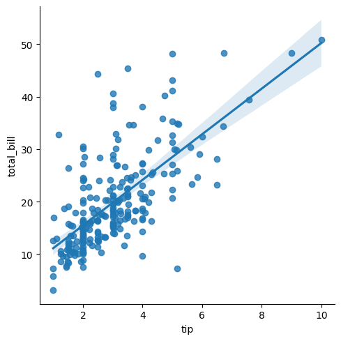

```python
# YOUR CODE HERE
sns.lmplot(x="tip", y="total_bill",  data=df);
```

### Q12❓On the previous plot, show the difference between `Dinner` and `Lunch` using different colors

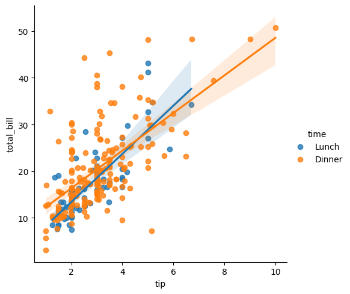

```python
# YOUR CODE HERE
sns.lmplot(x="tip", y="total_bill", hue="time", data=df);
```

### Q13❓ Which graph would you use to visualize the *dispersion* of the various `tip` that were given? Plot it

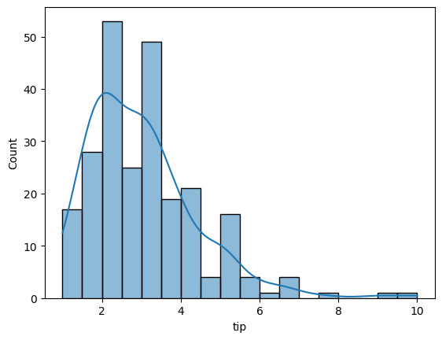

```python
# YOUR CODE HERE
sns.histplot(data=df,x=df['tip'], kde=True)
```

## 🏁 Congrats! Go back on Kitt to read final instructions to submit your notebook